# ІДЕНТИФІКАЦІЯ ПОТЕНЦІЙНИХ БІОМАРКЕРІВ ДЛЯ РАННЬОЇ ДІАГНОСТИКИ РАКУ МОЛОЧНОЇ ЗАЛОЗИ

Руденко Милана

2025-12-13

Для проведення біоінформатичного аналізу було підготовлено програмне середовище R із використанням пакетів Bioconductor та CRAN, необхідних для обробки транскриптомних даних, функціонального аналізу та машинного навчання.

```r
# 3.1.1. ПІДГОТОВКА СЕРЕДОВИЩА

if (!requireNamespace("BiocManager", quietly = TRUE))
  install.packages("BiocManager")

bioc_pkgs <- c(
  "GEOquery", "limma", "hgu133plus2.db",
  "clusterProfiler", "org.Hs.eg.db", "ReactomePA"
)

cran_pkgs <- c(
  "ggplot2", "pheatmap", "dplyr", "tibble",
  "caret", "randomForest", "pROC"
)

for(p in bioc_pkgs) if(!requireNamespace(p, quietly=TRUE)) BiocManager::install(p)
```

```
## Setting options('download.file.method.GEOquery'='auto')
```

```
## Setting options('GEOquery.inmemory.gpl'=FALSE)
```

```r
for(p in cran_pkgs) if(!requireNamespace(p, quietly=TRUE)) install.packages(p)

library(GEOquery)
library(limma)
library(hgu133plus2.db)
library(clusterProfiler)
library(org.Hs.eg.db)
library(ReactomePA)
```

```r
library(ggplot2)
library(pheatmap)
library(dplyr)
library(tibble)
library(caret)
library(randomForest)
library(pROC)
```

Транскриптомні дані молочної залози було отримано з бази GEO (набір GSE15852), що містить профілі експресії генів для нормальних та пухлинних зразків. У результаті сформовано матрицю експресії генів та метадані з інформацією про групи зразків.

```r
# 3.1.2. ЗАВАНТАЖЕННЯ ТА ОЧИСТКА ДАНИХ

gset <- getGEO("GSE15852", GSEMatrix = TRUE)[[1]]
```

```
## Found 1 file(s)
```

```
## GSE15852_series_matrix.txt.gz
```

```r
expr_matrix <- exprs(gset)
metadata <- pData(gset)

metadata$group <- ifelse(
  grepl("Normal", metadata$title, ignore.case = TRUE),
  "Normal", "Tumor"
)
metadata$group <- factor(metadata$group)

table(metadata$group)
```

```
##
## Normal  Tumor
##     43     43
```

Для забезпечення коректного аналізу було виконано узгодження порядку зразків між експресійною матрицею та метаданими, а також усунено технічні дублікати проб.

```r
# 3.1.3. УЗГОДЖЕННЯ ПОРЯДКУ

common_samples <- intersect(colnames(expr_matrix), rownames(metadata))
expr_matrix <- expr_matrix[, common_samples]
metadata <- metadata[common_samples, ]

stopifnot(all(colnames(expr_matrix) == rownames(metadata)))

# Числовий формат
expr_matrix <- as.matrix(expr_matrix)
mode(expr_matrix) <- "numeric"

# Видалення дублікатів probe
expr_matrix <- expr_matrix[!duplicated(rownames(expr_matrix)), ]
```

Для первинної оцінки якості даних побудовано boxplot розподілу експресії генів, що дозволяє перевірити однорідність та відсутність технічних зсувів між зразками.

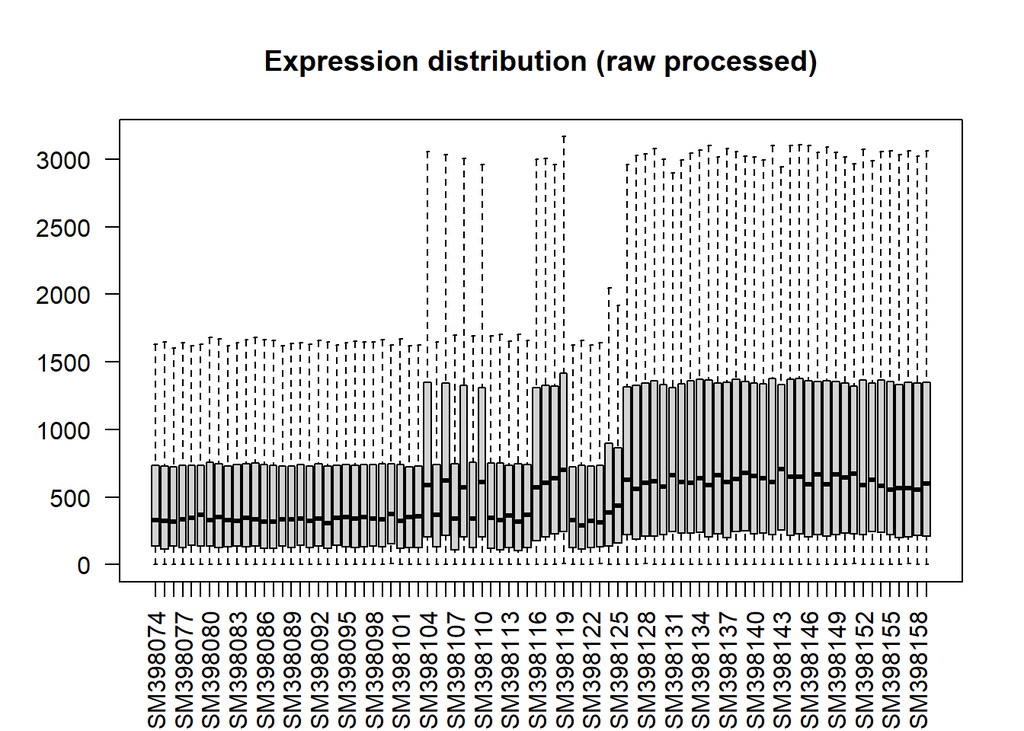

```r
# 3.1.4. КОНТРОЛЬ ЯКОСТІ: BOXPLOT

# Дані вже log2 normalized (GEO processed)
boxplot(expr_matrix, outline = FALSE, las = 2,
        main = "Expression distribution (raw processed)")
```

Аналіз головних компонент (PCA) застосовано для візуалізації загальної структури даних та оцінки розділення між нормальними і пухлинними зразками.

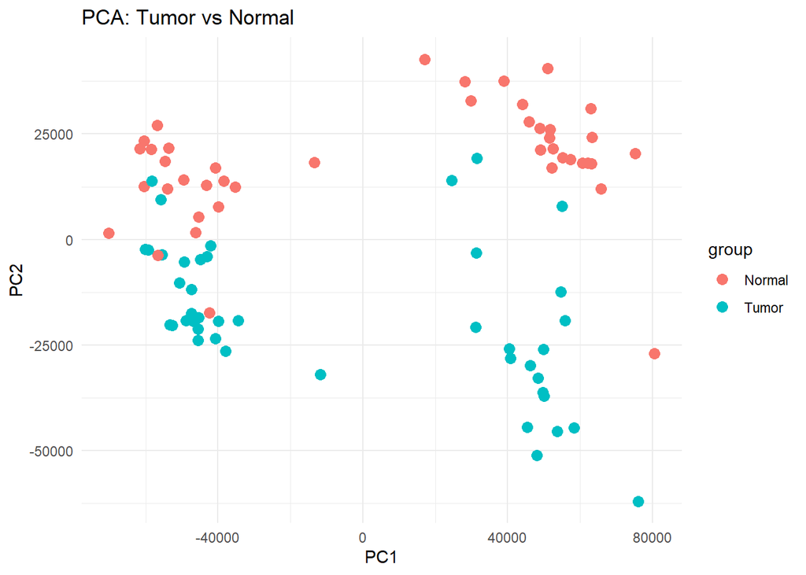

```r
# 3.1.5. КОНТРОЛЬ ЯКОСТІ: PCA

pca <- prcomp(t(expr_matrix))
pca_df <- data.frame(
  PC1 = pca$x[,1],
  PC2 = pca$x[,2],
  group = metadata$group
)

ggplot(pca_df, aes(PC1, PC2, color = group)) +
  geom_point(size = 3) +
  theme_minimal() +
  ggtitle("PCA: Tumor vs Normal")
```

Для ідентифікації диференційно експресованих генів між групами Tumor та Normal використано лінійні моделі пакета limma з корекцією на множинне тестування.

```r
# 3.2.1. DEGs - LIMMA

design <- model.matrix(~ group, data = metadata)
fit <- lmFit(expr_matrix, design)
fit <- eBayes(fit)

deg_all <- topTable(
  fit,
  coef = "groupTumor",
  number = Inf,
  adjust.method = "BH"
) %>% rownames_to_column("ProbeID")

deg_sig <- deg_all %>%
  filter(adj.P.Val < 0.05 & abs(logFC) >= 1)

nrow(deg_sig)
```

```
## [1] 1658
```

Отримано перелік генів зі статистично значущими змінами рівня експресії.

```r
# 3.2.2. ТАБЛИЦЯ ЗНАЧУЩИХ DEGs

deg_sig %>%
  select(ProbeID, logFC, adj.P.Val) %>%
  arrange(adj.P.Val) %>%
  head(15)
```

```
##        ProbeID     logFC    adj.P.Val
## 1     43427_at -1949.542 8.786291e-11
## 2     49452_at -2645.656 8.786291e-11
## 3  203548_s_at -3561.456 1.215624e-10
## 4    207092_at -2439.537 1.727120e-10
## 5  219140_s_at -2910.603 1.973600e-10
## 6  209699_x_at -4107.894 3.088366e-10
## 7  215695_s_at -2692.134 5.522515e-10
## 8    203980_at -5179.062 5.654899e-10
## 9  205382_s_at -4092.264 6.651494e-10
## 10   207175_at -4117.255 7.168019e-10
## 11 210964_s_at -1752.235 7.432735e-10
## 12   205913_at -3188.122 8.656877e-10
## 13 204388_s_at -1124.753 9.359902e-10
## 14 218087_s_at -2470.966 9.841155e-10
## 15 210201_x_at -1094.570 1.570497e-09
```

Volcano plot використано для наочного представлення результатів диференційного аналізу з урахуванням величини змін експресії та статистичної значущості.

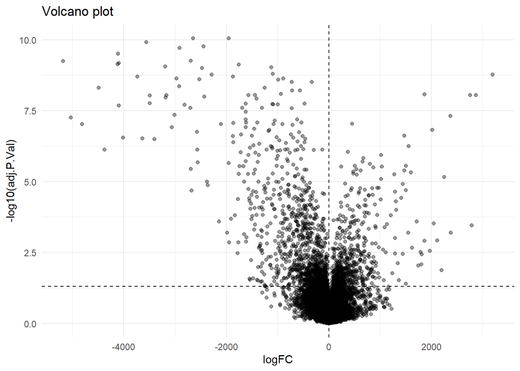

```r
# 3.2.3. VOLCANO PLOT

ggplot(deg_all, aes(logFC, -log10(adj.P.Val))) +
  geom_point(alpha = 0.4) +
  geom_vline(xintercept = c(-1,1), linetype = "dashed") +
  geom_hline(yintercept = -log10(0.05), linetype = "dashed") +
  theme_minimal() +
  ggtitle("Volcano plot")
```

Для біологічної інтерпретації диференційно експресованих генів було виконано анотацію проб мікрочипа GPL570 з використанням офіційних генних символів та ідентифікаторів Entrez.

```r
# 3.3.1. АНОТАЦІЯ GPL570

annot <- AnnotationDbi::select(
  hgu133plus2.db,
  keys = deg_sig$ProbeID,
  columns = c("SYMBOL", "ENTREZID", "GENENAME"),
  keytype = "PROBEID"
)
annot <- annot %>%
  filter(!is.na(SYMBOL)) %>%
  distinct(PROBEID, .keep_all = TRUE) %>%
  rename(ProbeID = PROBEID)

deg_annot <- left_join(deg_sig, annot, by = "ProbeID")

head(deg_annot)
```

```
##       ProbeID     logFC  AveExpr         t      P.Value    adj.P.Val         B
## 1    43427_at -1949.542 1445.796 -9.449621 6.543175e-15 8.786291e-11 -4.215142
## 2    49452_at -2645.656 2374.596 -9.409580 7.886093e-15 8.786291e-11 -4.216761
## 3 203548_s_at -3561.456 2560.386 -9.253034 1.636616e-14 1.215624e-10 -4.223160
## 4   207092_at -2439.537 1635.743 -9.116105 3.100337e-14 1.727120e-10 -4.228846
## 5 219140_s_at -2910.603 1756.584 -9.039698 4.428488e-14 1.973600e-10 -4.232055
## 6 209699_x_at -4107.894 3408.483 -8.904669 8.315846e-14 3.088366e-10 -4.237790
##   SYMBOL ENTREZID                               GENENAME
## 1  ACACB       32            acetyl-CoA carboxylase beta
## 2  ACACB       32            acetyl-CoA carboxylase beta
## 3    LPL     4023                     lipoprotein lipase
## 4    LEP     3952                                 leptin
## 5   RBP4     5950              retinol binding protein 4
## 6 AKR1C2     1646 aldo-keto reductase family 1 member C2
```

Для виявлення біологічних процесів та сигнальних шляхів, асоційованих із виявленими DEGs, проведено аналіз функціонального збагачення за базами Gene Ontology та Reactome.

```r
# 3.3.2. ФУНКЦІОНАЛЬНИЙ АНАЛІЗ

entrez_genes <- unique(na.omit(deg_annot$ENTREZID))
length(entrez_genes)
```

```
## [1] 1382
```

```r
ego <- enrichGO(
  gene = entrez_genes,
  OrgDb = org.Hs.eg.db,
  ont = "BP",
  pAdjustMethod = "BH",
  readable = TRUE
)

ereact <- enrichPathway(
  gene = entrez_genes,
  organism = "human"
)
```

Візуалізація результатів функціонального аналізу дозволяє визначити ключові біологічні процеси та молекулярні механізми, пов’язані з розвитком раку молочної залози.

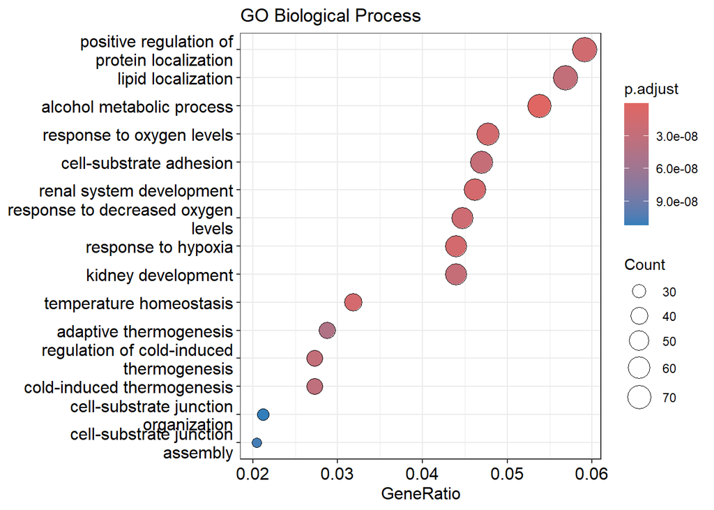

```r
# 3.3.3. ФУНКЦІОНАЛЬНИЙ АНАЛІЗ: ВІЗУАЛІЗАЦІЯ

enrichplot::dotplot(ego, showCategory = 15) +
  ggtitle("GO Biological Process")
```

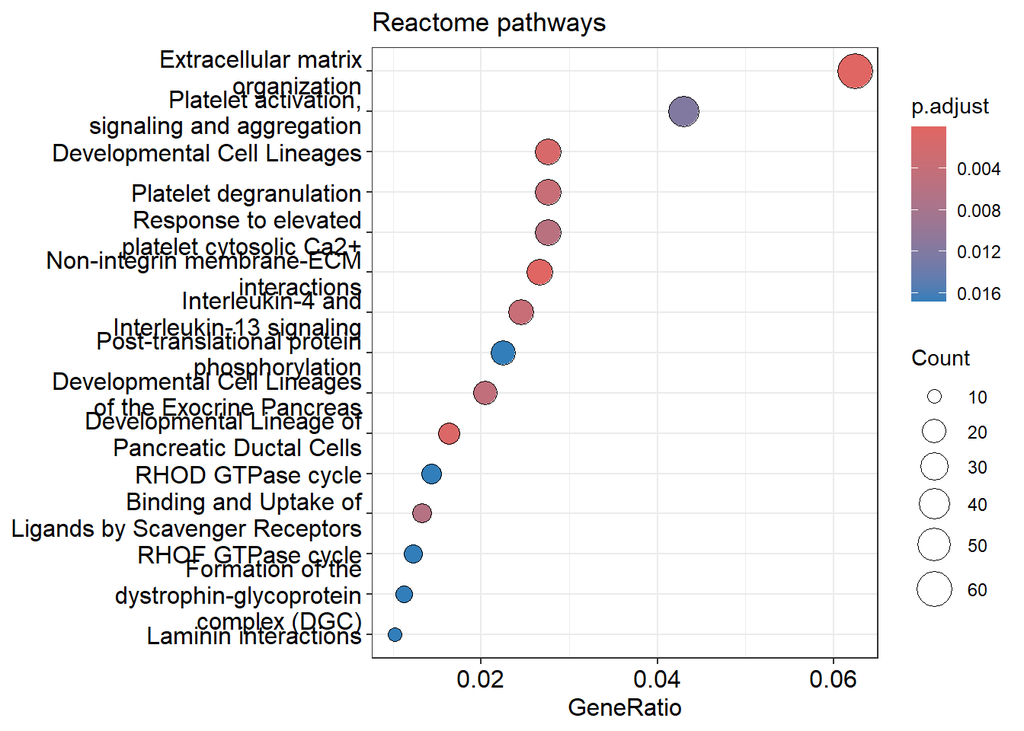

```r
enrichplot::dotplot(ereact, showCategory = 15) +
  ggtitle("Reactome pathways")
```

На основі величини змін експресії та статистичної значущості сформовано список потенційних біомаркерів, найбільш характерних для пухлинного фенотипу.

```r
# 3.4.1. ВІДБІР ПОТЕНЦІЙНИХ БІОМАРКЕРІВ

candidates <- deg_annot %>%
  filter(abs(logFC) >= 1, adj.P.Val < 0.05) %>%
  arrange(adj.P.Val, desc(abs(logFC)))

shortlist <- candidates %>% head(20)
shortlist$SYMBOL
```

```
##  [1] "ACACB"   "ACACB"   "LPL"     "LEP"     "RBP4"    "AKR1C2"  "GYG2"
##  [8] "FABP4"   "CFD"     "ADIPOQ"  "GYG2"    "PLIN1"   "MAOA"    "SORBS1"
## [15] "BIN1"    "CD24"    "PCOLCE2" "LPL"     "AOC3"    "G0S2"
```

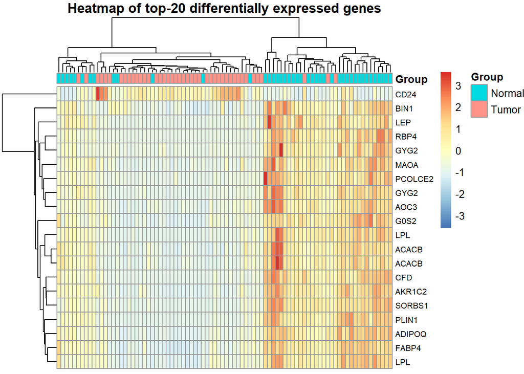

```r
# 3.4.2. HEATMAP ТОП-БІОМАРКЕРІВ

# Проби для short-list
heat_probes <- shortlist$ProbeID

# Матриця експресії
heat_mat <- expr_matrix[heat_probes, , drop = FALSE]

# Назви рядків = гени
rownames(heat_mat) <- deg_annot$SYMBOL[
  match(heat_probes, deg_annot$ProbeID)
]

# Анотація зразків
ann_col <- data.frame(
  Group = metadata$group
)
rownames(ann_col) <- colnames(heat_mat)

# Побудова heatmap
pheatmap(
  heat_mat,
  scale = "row",
  annotation_col = ann_col,
  show_colnames = FALSE,
  fontsize_row = 8,
  main = "Heatmap of top-20 differentially expressed genes"
)
```

Для підвищення стабільності моделей виконано додатковий фільтр диференційно експресованих генів за більш жорсткими статистичними критеріями.

```r
# 3.5.1. ПОПЕРЕДНІЙ СТАТИСТИЧНИЙ ВІДБІР (DEGs)

deg_filtered <- deg_annot %>%
  filter(
    adj.P.Val < 0.01,
    abs(logFC) >= 1
  ) %>%
  distinct(SYMBOL, .keep_all = TRUE)

nrow(deg_filtered)
```

```
## [1] 701
```

```r
head(deg_filtered[, c("SYMBOL", "logFC", "adj.P.Val")])
```

```
##   SYMBOL     logFC    adj.P.Val
## 1  ACACB -1949.542 8.786291e-11
## 2    LPL -3561.456 1.215624e-10
## 3    LEP -2439.537 1.727120e-10
## 4   RBP4 -2910.603 1.973600e-10
## 5 AKR1C2 -4107.894 3.088366e-10
## 6   GYG2 -2692.134 5.522515e-10
```

На основі скоригованих p-значень сформовано початкову панель із 50 найбільш інформативних генів для подальшого машинного навчання.

```r
# 3.5.2. ФОРМУВАННЯ ПОЧАТКОВОЇ ПАНЕЛІ (TOP-50)

initial_panel <- deg_filtered %>%
  arrange(adj.P.Val) %>%
  head(50)

initial_panel$SYMBOL
```

```
##  [1] "ACACB"   "LPL"     "LEP"     "RBP4"    "AKR1C2"  "GYG2"    "FABP4"
##  [8] "CFD"     "ADIPOQ"  "PLIN1"   "MAOA"    "SORBS1"  "BIN1"    "PCOLCE2"
## [15] "CD24"    "AOC3"    "COQ8A"   "G0S2"    "ADIRF"   "ANGPTL4" "HCAR3"
## [22] "CIDEC"   "AKR1C1"  "PPP1R1A" "PCDH9"   "PDE3B"   "COX7A1"  "EPCAM"
## [29] "ITIH5"   "RARRES2" "TNS1"    "TACSTD2" "CD36"    "CAV2"    "PDZD2"
## [36] "ADH1B"   "ABCA8"   "PPARG"   "FHL1"    "RGCC"    "SAA2"    "HBA1"
## [43] "CHRDL1"  "PCK1"    "WASF3"   "CAV1"    "HBB"     "AKAP12"  "GAB2"
## [50] "PALMD"
```

Експресійні значення проб було агреговано на рівні генів, що дозволило сформувати зручну матрицю ознак для моделей машинного навчання.

```r
# 3.5.3. ФОРМУВАННЯ МАТРИЦІ ОЗНАК

probe_gene_map <- deg_annot %>%
  filter(SYMBOL %in% initial_panel$SYMBOL) %>%
  select(ProbeID, SYMBOL)

expr_sub <- expr_matrix[probe_gene_map$ProbeID, , drop = FALSE]
expr_df <- as.data.frame(expr_sub)
expr_df$Gene <- probe_gene_map$SYMBOL

expr_gene <- expr_df %>%
  group_by(Gene) %>%
  summarise(across(where(is.numeric), mean), .groups = "drop")

X_panel <- t(as.matrix(expr_gene[, -1]))
colnames(X_panel) <- expr_gene$Gene

y <- factor(metadata$group, levels = c("Normal", "Tumor"))

# Перевірка балансу класів
table(y)
```

```
## y
## Normal  Tumor
##     43     43
```

```r
prop.table(table(y))
```

```
## y
## Normal  Tumor
##    0.5    0.5
```

Алгоритм Random Forest використано для оцінки важливості кожного гена та зменшення розмірності ознакового простору.

```r
# 3.6.1. НАВЧАННЯ Random Forest ДЛЯ ОЦІНКИ ВАЖЛИВОСТІ ГЕНІВ

set.seed(123)

rf_fs <- randomForest(
  x = X_panel,
  y = y,
  ntree = 500,
  importance = TRUE
)

rf_importance <- importance(rf_fs) %>%
  as.data.frame() %>%
  rownames_to_column("Gene") %>%
  arrange(desc(MeanDecreaseGini))

head(rf_importance, 10)
```

```
##       Gene   Normal    Tumor MeanDecreaseAccuracy MeanDecreaseGini
## 1  PPP1R1A 7.999283 6.342345             9.351949         2.785629
## 2    PCDH9 5.439625 7.090634             8.576740         2.735862
## 3      LEP 5.525609 5.483376             7.484836         2.606223
## 4     CD24 6.000010 8.073738             9.859235         1.994276
## 5    ACACB 6.685285 3.055134             7.411732         1.894950
## 6  ANGPTL4 7.867050 2.598223             7.815177         1.829570
## 7     BIN1 4.298447 4.885072             6.008979         1.818475
## 8      CFD 3.073895 1.938672             3.717176         1.745763
## 9     RBP4 3.959135 4.407820             5.744440         1.653125
## 10 PCOLCE2 4.099256 3.427200             4.968954         1.518672
```

За результатами оцінки важливості сформовано фінальну панель із 30 генів, що мають найбільший внесок у класифікацію зразків.

```r
# 3.6.2. ФІНАЛЬНА ПАНЕЛЬ ГЕНІВ (TOP-30)

final_genes <- rf_importance %>%
  head(30) %>%
  pull(Gene)

final_genes
```

```
##  [1] "PPP1R1A" "PCDH9"   "LEP"     "CD24"    "ACACB"   "ANGPTL4" "BIN1"
##  [8] "CFD"     "RBP4"    "PCOLCE2" "TACSTD2" "HCAR3"   "EPCAM"   "GYG2"
## [15] "PLIN1"   "COQ8A"   "AOC3"    "RARRES2" "CIDEC"   "ADIRF"   "PCK1"
## [22] "AKR1C2"  "PPARG"   "ADIPOQ"  "GAB2"    "G0S2"    "PDE3B"   "ITIH5"
## [29] "RGCC"    "PALMD"
```

На основі фінальної панелі генів побудовано остаточну матрицю ознак, яка використовується для навчання та тестування моделей.

```r
# 3.6.3. МАТРИЦЯ ОЗНАК ДЛЯ ML (30 генів)

# Витягуємо відповідність probe → gene
probe_gene_map <- deg_annot %>%
  filter(SYMBOL %in% final_genes) %>%
  select(ProbeID, SYMBOL)

# Вибираємо експресію потрібних probe
expr_sub <- expr_matrix[probe_gene_map$ProbeID, , drop = FALSE]

# Додаємо назви генів
expr_df <- as.data.frame(expr_sub)
expr_df$Gene <- probe_gene_map$SYMBOL

# Агрегація: один ген = одне значення (mean)
expr_gene <- expr_df %>%
  group_by(Gene) %>%
  summarise(across(where(is.numeric), mean), .groups = "drop")

# Формуємо фінальну матрицю (samples × genes)
X_final <- t(as.matrix(expr_gene[, -1]))
colnames(X_final) <- expr_gene$Gene

dim(X_final)
```

```
## [1] 86 30
```

```r
# Фінальна матриця ознак (фрагмент)
knitr::kable(
  head(X_final),
  digits = 3,
  caption = "Фрагмент фінальної матриці ознак (зразки × 30 генів)"
)
```

Фрагмент фінальної матриці ознак (зразки × 30 генів)

|  | ACACB | ADIPOQ | ADIRF | AKR1C2 | ANGPTL4 | AOC3 | BIN1 | CD24 | CFD | CIDEC | COQ8A | EPCAM | G0S2 | GAB2 | GYG2 | HCAR3 | ITIH5 | LEP | PALMD | PCDH9 | PCK1 | PCOLCE2 | PDE3B | PLIN1 | PPARG | PPP1R1A | RARRES2 | RBP4 | RGCC | … |
| --- | --- | --- | --- | --- | --- | --- | --- | --- | --- | --- | --- | --- | --- | --- | --- | --- | --- | --- | --- | --- | --- | --- | --- | --- | --- | --- | --- | --- | --- | --- |
| GSM398074 | 435.405 | 772.854 | 57.537 | 376.889 | 78.879 | 524.535 | 1005.193 | 1129.275 | 130.555 | 2072.110 | 95.941 | 983.916 | 1222.660 | 674.590 | 521.081 | 203.039 | 553.432 | 72.114 | 198.575 | 281.987 | 163.479 | 447.373 | 294.043 | 360.352 | 114.029 | 142.144 | 91.004 | 105.063 | 418.662 | … |
| GSM398075 | 727.483 | 750.625 | 112.880 | 583.544 | 65.608 | 659.933 | 559.224 | 2636.923 | 200.888 | 629.868 | 386.339 | 1996.560 | 873.514 | 676.611 | 399.038 | 319.036 | 463.231 | 103.922 | 1033.680 | 238.714 | 47.452 | 271.123 | 266.024 | 218.455 | 75.093 | 111.928 | 330.605 | 81.724 | 1288.110 | … |
| GSM398076 | 920.100 | 1973.180 | 379.280 | 531.708 | 68.447 | 1846.590 | 342.596 | 384.479 | 227.837 | 2081.680 | 229.736 | 470.340 | 1823.890 | 857.683 | 523.478 | 492.563 | 630.486 | 131.461 | 1689.780 | 279.038 | 475.585 | 738.146 | 336.747 | 747.811 | 174.469 | 126.522 | 97.943 | 70.647 | 657.279 | … |
| GSM398077 | 194.589 | 756.890 | 160.451 | 80.875 | 39.541 | 343.638 | 167.383 | 3406.119 | 46.616 | 1917.570 | 96.284 | 2423.280 | 476.268 | 203.162 | 364.608 | 195.035 | 251.363 | 123.528 | 129.722 | 383.858 | 175.239 | 189.011 | 497.803 | 448.317 | 61.460 | 102.474 | 146.464 | 49.157 | 333.873 | … |
| GSM398078 | 1971.171 | 3291.020 | 239.262 | 1637.055 | 259.270 | 2072.610 | 370.037 | 745.160 | 2717.450 | 2427.200 | 408.256 | 250.448 | 2736.710 | 754.543 | 1316.748 | 276.609 | 892.100 | 603.287 | 1143.930 | 208.221 | 1582.030 | 1251.550 | 462.994 | 2181.840 | 272.417 | 878.394 | 759.854 | 603.827 | 1219.600 | … |
| GSM398079 | 347.078 | 491.799 | 521.163 | 114.264 | 39.740 | 559.088 | 143.882 | 2815.389 | 78.113 | 1355.860 | 110.024 | 2857.520 | 720.651 | 581.028 | 368.060 | 295.170 | 323.208 | 122.551 | 144.425 | 89.070 | 143.930 | 87.388 | 375.104 | 262.199 | 43.218 | 50.258 | 294.662 | 58.925 | 372.964 | … |

Дані було випадково поділено на навчальну та тестову вибірки для первинної оцінки узагальнювальної здатності моделей.

```r
# 3.7.1. TRAIN/TEST SPLIT

set.seed(123)
train_id <- createDataPartition(y, p = 0.7, list = FALSE)

X_train <- X_final[train_id, , drop = FALSE]
X_test  <- X_final[-train_id, , drop = FALSE]

y_train <- y[train_id]
y_test  <- y[-train_id]

table(y_train)
```

```
## y_train
## Normal  Tumor
##     31     31
```

```r
table(y_test)
```

```
## y_test
## Normal  Tumor
##     12     12
```

Для біологічної інтерпретації фінальної панелі генів виконано зіставлення з ідентифікаторами Entrez.

```r
# 3.7.2. ФУНКЦІОНАЛЬНИЙ АНАЛІЗ ФІНАЛЬНОЇ ПАНЕЛІ ГЕНІВ

final_entrez <- AnnotationDbi::select(
  org.Hs.eg.db,
  keys = final_genes,
  columns = "ENTREZID",
  keytype = "SYMBOL"
) %>%
  filter(!is.na(ENTREZID)) %>%
  pull(ENTREZID) %>%
  unique()
length(final_entrez)
```

```
## [1] 30
```

```r
final_entrez
```

```
##  [1] "5502"      "5101"      "3952"      "100133941" "32"        "51129"
##  [7] "274"       "1675"      "5950"      "26577"     "4070"      "8843"
## [13] "4072"      "8908"      "5346"      "56997"     "8639"      "5919"
## [19] "63924"     "10974"     "5105"      "1646"      "5468"      "9370"
## [25] "9846"      "50486"     "5140"      "80760"     "28984"     "54873"
```

Аналіз GO Biological Process дозволяє виявити ключові клітинні процеси, асоційовані з відібраною панеллю біомаркерів.

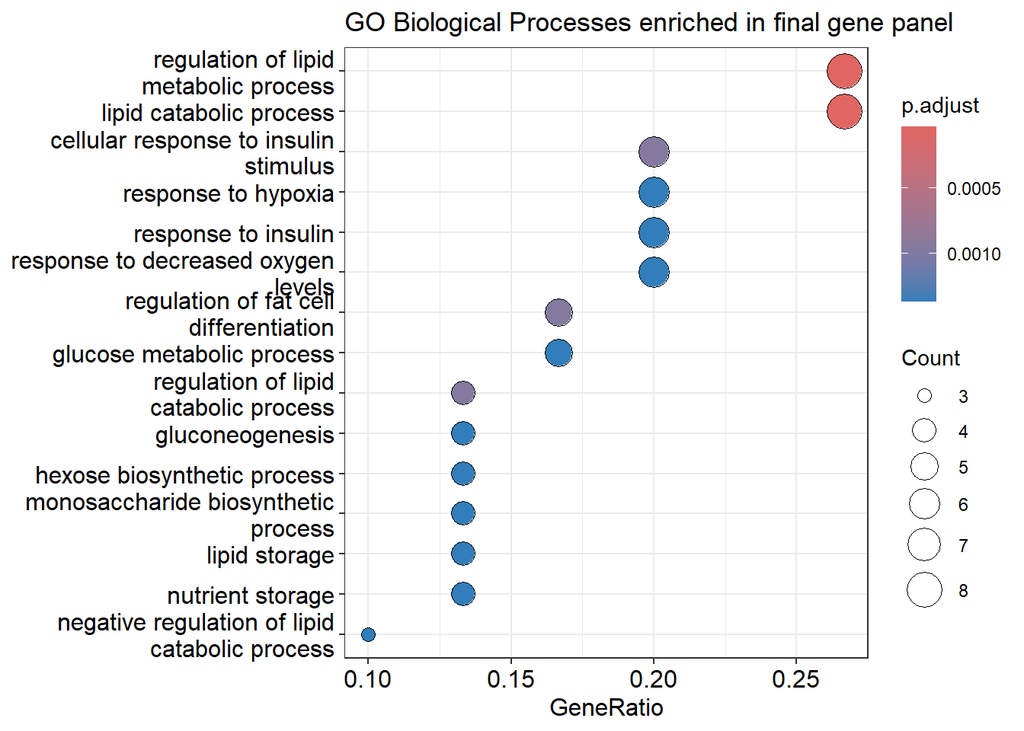

```r
# 3.7.3. GO Biological Process (інтерпретація)

ego_final <- enrichGO(
  gene = final_entrez,
  OrgDb = org.Hs.eg.db,
  ont = "BP",
  pAdjustMethod = "BH",
  readable = TRUE
)

enrichplot::dotplot(
  ego_final,
  showCategory = 15
) +
  ggtitle("GO Biological Processes enriched in final gene panel")
```

Аналіз сигнальних шляхів Reactome дає змогу ідентифікувати молекулярні каскади, залучені до канцерогенезу молочної залози.

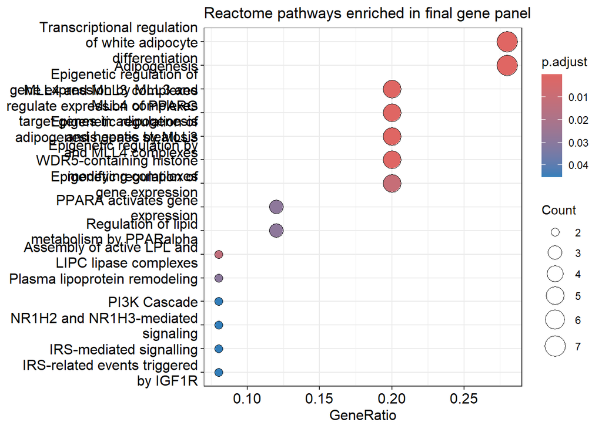

```r
# 3.7.4. REACTOME PATHWAYS (сигнальні шляхи)

ereact_final <- enrichPathway(
  gene = final_entrez,
  organism = "human",
  pAdjustMethod = "BH",
  readable = TRUE
)

enrichplot::dotplot(
  ereact_final,
  showCategory = 15
) +
  ggtitle("Reactome pathways enriched in final gene panel")
```

Модель Random Forest використано для класифікації зразків на основі фінальної панелі генів та оцінки її діагностичної ефективності.

```r
# 3.8.1. RANDOM FOREST

rf <- randomForest(
  x = X_train,
  y = y_train,
  ntree = 500,
  importance = TRUE
)

prob_rf <- predict(rf, X_test, type = "prob")[,"Tumor"]
roc_rf <- roc(y_test, prob_rf)
```

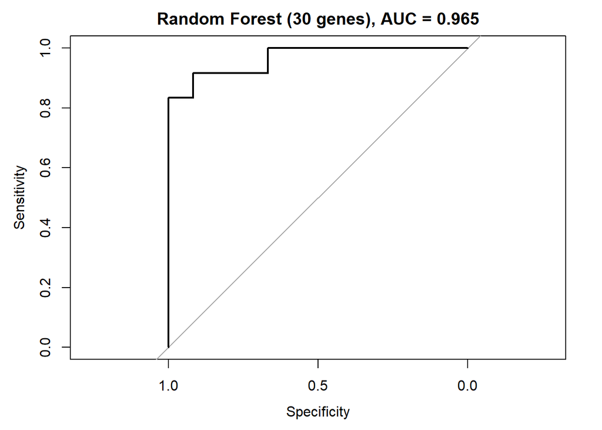

```r
plot(
  roc_rf,
  main = paste("Random Forest (30 genes), AUC =",
               round(auc(roc_rf), 3))
)
```

```r
confusionMatrix(
  factor(ifelse(prob_rf > 0.5, "Tumor", "Normal"),
         levels = c("Normal", "Tumor")),
  y_test
)
```

```
## Confusion Matrix and Statistics
##
##           Reference
## Prediction Normal Tumor
##     Normal     10     1
##     Tumor       2    11
##
##                Accuracy : 0.875
##                  95% CI : (0.6764, 0.9734)
##     No Information Rate : 0.5
##     P-Value [Acc > NIR] : 0.0001386
##
##                   Kappa : 0.75
##
##  Mcnemar's Test P-Value : 1.0000000
##
##             Sensitivity : 0.8333
##             Specificity : 0.9167
##          Pos Pred Value : 0.9091
##          Neg Pred Value : 0.8462
##              Prevalence : 0.5000
##          Detection Rate : 0.4167
##    Detection Prevalence : 0.4583
##       Balanced Accuracy : 0.8750
##
##        'Positive' Class : Normal
##
```

Аналіз важливості ознак дозволяє визначити гени, які найбільше впливають на прийняття рішень моделлю.

```r
# 3.8.2. RANDOM FOREST

importance(rf) %>%
  as.data.frame() %>%
  rownames_to_column("Gene") %>%
  arrange(desc(MeanDecreaseGini)) %>%
  head(10)
```

```
##       Gene   Normal    Tumor MeanDecreaseAccuracy MeanDecreaseGini
## 1    ACACB 7.208738 8.512769            10.165096         3.455878
## 2    PCDH9 6.652240 7.706387             9.488817         2.945666
## 3     CD24 9.131530 5.787243            10.345463         2.099053
## 4      LEP 4.302414 5.786396             7.199880         1.720362
## 5      CFD 1.915054 1.479495             2.136223         1.439578
## 6     RBP4 5.750624 2.975414             5.842098         1.360876
## 7  PCOLCE2 4.737721 2.501651             4.809315         1.298291
## 8  ANGPTL4 6.594988 1.439366             6.526178         1.298227
## 9  PPP1R1A 6.295765 3.559826             7.139261         1.235264
## 10   CIDEC 3.891030 1.288703             3.375771         1.165045
```

Для коректного навчання нейромережі виконано масштабування ознак та перетворення класів у числовий формат.

```r
# 3.9.1. ПІДГОТОВКА ДАНИХ ДЛЯ НЕЙРОМЕРЕЖІ

# Масштабування ознак
X_scaled <- scale(X_final)

# Класи у числовому форматі
y_num <- ifelse(y == "Tumor", 1, 0)

# Train / test
X_train_nn <- X_scaled[train_id, , drop = FALSE]
X_test_nn  <- X_scaled[-train_id, , drop = FALSE]

y_train_nn <- y_num[train_id]
y_test_nn  <- y_num[-train_id]
```

Багатошарову нейромережу навчено для класифікації зразків з оцінкою її здатності розрізняти пухлинні та нормальні тканини.

```r
# 3.9.2. НЕЙРОМЕРЕЖЕВА МОДЕЛЬ (MLP)

library(nnet)
library(pROC)
library(caret)

set.seed(123)

nn_model <- nnet(
  x = X_train_nn,
  y = y_train_nn,
  size = 10,
  decay = 0.01,
  maxit = 500,
  linout = FALSE
)
nn_prob <- predict(nn_model, X_test_nn, type = "raw")
roc_nn <- roc(y_test_nn, nn_prob)
```

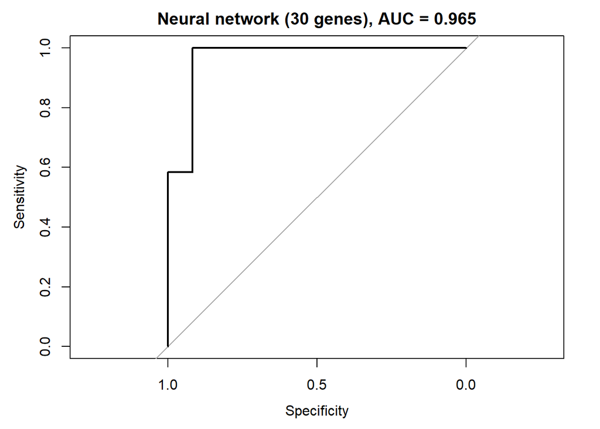

```r
plot(
  roc_nn,
  main = paste("Neural network (30 genes), AUC =",
               round(auc(roc_nn), 3))
)
```

Якість нейромережевої моделі оцінено за допомогою ROC-кривої, AUC та матриці неточностей.

```r
# 3.9.3. ОЦІНКА ЯКОСТІ НЕЙРОМЕРЕЖІ

# Ймовірності
nn_prob <- predict(nn_model, X_test_nn, type = "raw")

# Класи
nn_pred <- ifelse(nn_prob > 0.5, 1, 0)

# Матриця неточностей
table(
  Predicted = nn_pred,
  Actual = y_test_nn
)
```

```
##          Actual
## Predicted  0  1
##         0 11  2
##         1  1 10
```

Для отримання стабільної оцінки якості класифікації застосовано 5-кратну перехресну валідацію.

```r
# 3.9.4. ПЕРЕХРЕСНА ВАЛІДАЦІЯ НЕЙРОМЕРЕЖІ

X_df <- as.data.frame(X_scaled)
colnames(X_df) <- make.unique(colnames(X_df))

library(caret)
library(pROC)

set.seed(123)

y_factor <- factor(
  ifelse(y == "Tumor", "Tumor", "Normal"),
  levels = c("Normal", "Tumor")
)

ctrl <- trainControl(
  method = "cv",
  number = 5,
  classProbs = TRUE,
  summaryFunction = twoClassSummary
)

nn_cv <- caret::train(
  x = X_df,
  y = y_factor,
  method = "nnet",
  trControl = ctrl,
  metric = "ROC",
  tuneGrid = data.frame(size = 5, decay = 0.01),
  linout = FALSE,
  trace = FALSE,
  maxit = 500
)

nn_cv
```

```
## Neural Network
##
## 86 samples
## 30 predictors
##  2 classes: 'Normal', 'Tumor'
##
## No pre-processing
## Resampling: Cross-Validated (5 fold)
## Summary of sample sizes: 68, 70, 69, 69, 68
## Resampling results:
##
##   ROC        Sens  Spec
##   0.8845679  0.7   0.7944444
##
## Tuning parameter 'size' was held constant at a value of 5
## Tuning
##  parameter 'decay' was held constant at a value of 0.01
```

```r
nn_cv$results
```

```
##   size decay       ROC Sens      Spec      ROCSD    SensSD     SpecSD
## 1    5  0.01 0.8845679  0.7 0.7944444 0.08869363 0.1987616 0.08640184
```

Незалежний транскриптомний набір із GEO використано для перевірки узагальнювальної здатності моделей на зовнішніх даних.

```r
# 3.10.1. ФУНКЦІЯ ПІДГОТОВКИ НЕЗАЛЕЖНОГО GEO-НАБОРУ

prepare_validation_set <- function(gse_id, genes, train_center, train_scale) {

  gset <- getGEO(gse_id, GSEMatrix = TRUE)[[1]]
  expr <- exprs(gset)
  meta <- pData(gset)

  meta$group <- ifelse(
    grepl("normal", meta$title, ignore.case = TRUE),
    "Normal", "Tumor"
  )
  meta$group <- factor(meta$group, levels = c("Normal", "Tumor"))

  # Анотація
  annot <- AnnotationDbi::select(
    hgu133plus2.db,
    keys = rownames(expr),
    columns = "SYMBOL",
    keytype = "PROBEID"
  ) %>% filter(!is.na(SYMBOL))

  probe_gene_map <- annot %>%
    filter(SYMBOL %in% genes)

  expr_sub <- expr[probe_gene_map$PROBEID, , drop = FALSE]
  expr_df <- as.data.frame(expr_sub)
  expr_df$Gene <- probe_gene_map$SYMBOL

  expr_gene <- expr_df %>%
    group_by(Gene) %>%
    summarise(across(where(is.numeric), mean), .groups = "drop")

  X_val <- t(as.matrix(expr_gene[, -1]))
  colnames(X_val) <- expr_gene$Gene

  X_val_scaled <- scale(
    X_val,
    center = train_center,
    scale  = train_scale
  )

  list(
    X = X_val,
    X_scaled = X_val_scaled,
    y = meta$group
  )
}
```

```r
# 3.10.2. ПАРАМЕТРИ МАСШТАБУВАННЯ З TRAIN-НАБОРУ

train_center <- attr(X_scaled, "scaled:center")
train_scale  <- attr(X_scaled, "scaled:scale")
```

Ефективність моделей оцінено на незалежному наборі шляхом обчислення ROC-кривих та AUC.

```r
# 3.10.3. ВАЛІДАЦІЙНІ НАБОРИ (GPL570)

val_GSE42568 <- prepare_validation_set(
  "GSE42568",
  final_genes,
  train_center,
  train_scale
)
```

```
## Found 1 file(s)
```

```
## GSE42568_series_matrix.txt.gz
```

```r
dim(val_GSE42568$X)
```

```
## [1] 121  30
```

```r
table(val_GSE42568$y)
```

```
##
## Normal  Tumor
##     17    104
```

```r
# 3.10.4. ОЦІНКА МОДЕЛЕЙ НА НЕЗАЛЕЖНИХ ДАНИХ. ФУНКЦІЯ ОЦІНКИ AUC

evaluate_models <- function(val_set) {

  prob_rf <- predict(rf, val_set$X, type = "prob")[,"Tumor"]
  auc_rf <- auc(roc(val_set$y, prob_rf))

  prob_nn <- predict(nn_model, val_set$X_scaled, type = "raw")
  auc_nn <- auc(
    roc(ifelse(val_set$y == "Tumor", 1, 0), prob_nn)
  )

  data.frame(
    RF_AUC = auc_rf,
    NN_AUC = auc_nn
  )
}
```

```r
# 3.10.5. РЕЗУЛЬТАТИ ВАЛІДАЦІЇ

auc_42568 <- evaluate_models(val_GSE42568)
validation_results <- data.frame(
  Dataset = "GSE42568",
  RF_AUC  = auc_42568$RF_AUC,
  NN_AUC  = auc_42568$NN_AUC
)

knitr::kable(
  validation_results,
  digits = 3,
  caption = "AUC ROC моделей на незалежному транскриптомному наборі GSE42568"
)
```

AUC ROC моделей на незалежному транскриптомному наборі GSE42568

| Dataset | RF_AUC | NN_AUC |
| --- | --- | --- |
| GSE42568 | 0.5 | 0.9191176 |

ROC-крива на незалежному наборі підтверджує здатність нейромережевої моделі узагальнюватися на нові транскриптомні дані.

```r
# 3.10.6. ROC-КРИВІ

roc_nn_42568 <- roc(
  ifelse(val_GSE42568$y == "Tumor", 1, 0),
  predict(nn_model, val_GSE42568$X_scaled, type = "raw")
)
```

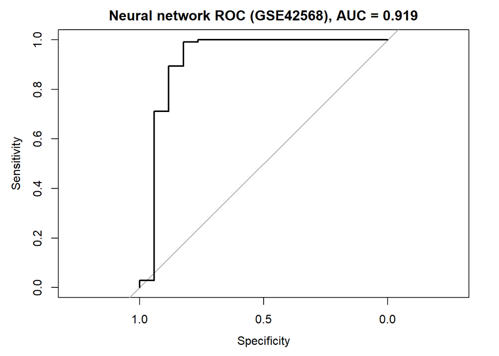

```r
plot(
  roc_nn_42568,
  main = paste(
    "Neural network ROC (GSE42568), AUC =",
    round(auc(roc_nn_42568), 3)
  )
)
```